# CitiBike Data

AnaPatricia Olvera

6/30/2020

Data from August 2019 and December 2019 was selected to be visualized. First, both CSV files were binded together:

```r
augDecData <-rbind( read.csv("citibikeData/RealData/201908-citibike-tripdata.csv"),
                    read.csv("citibikeData/RealData/201912-citibike-tripdata.csv"))
```

Next was separating Start Time and Stop Time into Start Data and Start Time

```r
augDecData <- augDecData%>% separate(starttime, c("start.date", "start.time"), " ")
augDecData <- augDecData%>% separate(stoptime, c("stop.date", "stop.time"), " ")
```

Using the *as.Date()* function, a new column Weekday was created. The *as.Date()* function take numeric data and represents it into calendar dates.

```r
augDecData$weekday <- weekdays(as.Date(augDecData$start.date))
```

The data was then cleaned, first all NA data was omitted

```r
augDecData <- augDecData%>% na.omit()
```

Second, filter the data so trip duration was less than 30 min

```r
augDecData <- augDecData %>% filter( tripduration >=0 & tripduration <= 1800)
```

Lastly, ages were also filtered, using only 70 and below.

```r
augDecData <- augDecData %>% filter( (2019 - birth.year ) <= 70)
```

There is a series a questions about the data that will be answer by visualization. Now, we can start plotting!

First, we plot the ages of the users:

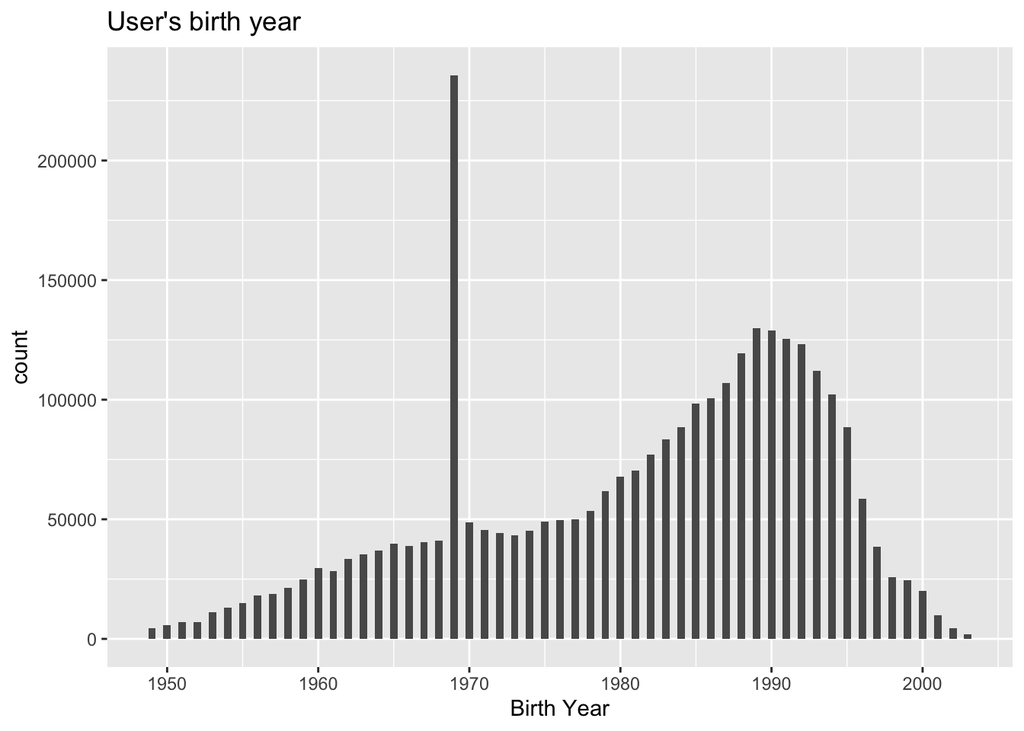

```r
ggplot(augDecData) + geom_histogram(mapping = aes( x= birth.year), stat = "bin",
  position = "stack", binwidth = 0.5,
  bins = 70,
  na.rm = T
) + labs(title= "User's birth year", x= "Birth Year")
```

The ages will be categorized for better use in the next plots: +Baby Boomer: 1946-1964 +Generation X: 1965-1979 +Generation Y (also known as Millennial): 1980-1996 +Generation Z: 1997-2010

To do this, a function that will sort the data was created:

```r
gen <- function(x){
  if(between(x,1946,1964)){
     return("baby boomer")
  }
  else if( between(x,1965,1979)){
    return("X")
  }
  else if(between(x,1980,1996)){
    return("Y")
  }
  if( x >= 1997){
    return("Z")
  }
}
```

Then, the data was sorted by generations.

```r
augDecData$generation <- sapply(augDecData$birth.year, gen)
```

Later, it was noticed that Gender, was numerical type. Using the key in the CitiBike page, genders were changed from Numerical to Character + 0= Unknown + 1= Male + 2= Female

```r
g <- function(y){
  if( y == 1){
    return("Male")
  }
  if( y== 2){
    return("Female")
  }
  if(y==0){
    return("Unknown")
  }
}
```

The again, the data was sorted by gender.

```r
augDecData$gender <- sapply(augDecData$gender, g)
```

Now, we plotted the gender of the users:

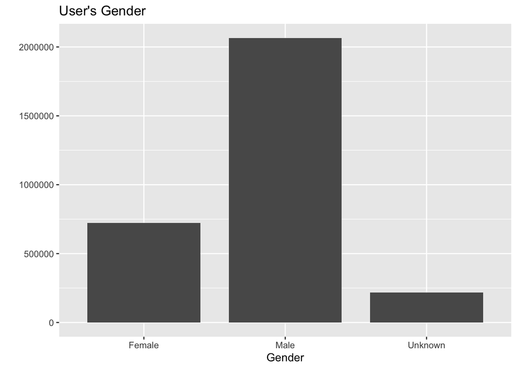

```r
ggplot(augDecData, aes(x= gender))+
         geom_bar(stat = "count", width = 0.80, na.rm = T ) + labs( title = "User's Gender", x = "Gender", y= "")
```

The majority of the users are Male.

Now we plot the gender and age of the users:

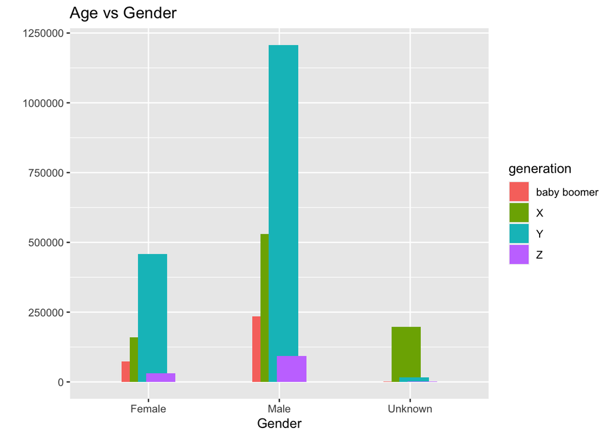

```r
ggplot(augDecData, aes(x= gender, fill= generation)) + geom_bar( stat = "count" , na.rm= T,
                                                              position = position_dodge(width = 0.25)) + labs(
                                                                title = "Age vs Gender", x= "Gender", y= "")
```

Majority of the users are Males between the ages of 39-23.

NExt, type of users was plot. + Customer: 24-hour pass or 3-day pass use ( $12 or $24 respectively) *There is also Single Ride option which cost $3 for 30 minutes.* + Subscriber: Annual Member ( $169 per year )

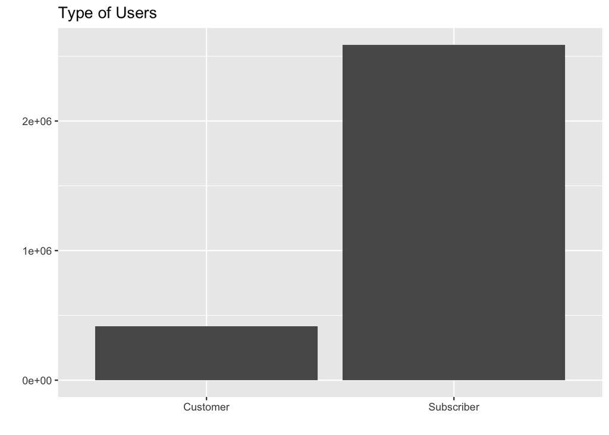

```r
ggplot(augDecData)+ geom_bar( aes(x= usertype), stat = "count", na.rm = T) + labs( title = "Type of Users", x= "", y = "")
```

Next, the gender of the type of users was plot:

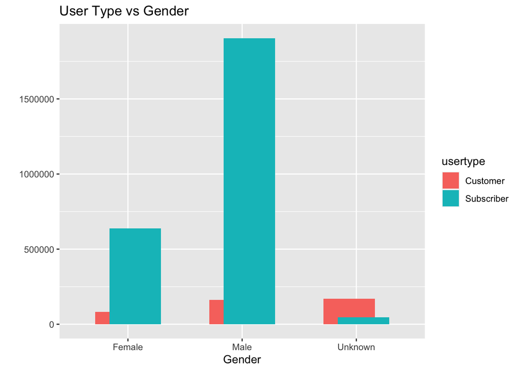

```r
ggplot(augDecData, aes(x= gender,fill= usertype)) + geom_bar( stat = "count" , na.rm= T,
                                                              position = position_dodge(width = 0.25)) + labs(
                                                                title= "User Type vs Gender", x= "Gender", y= "")
```

The majority of subscribers are male. The majority of customers are unknown.

Plotting user type’s age:

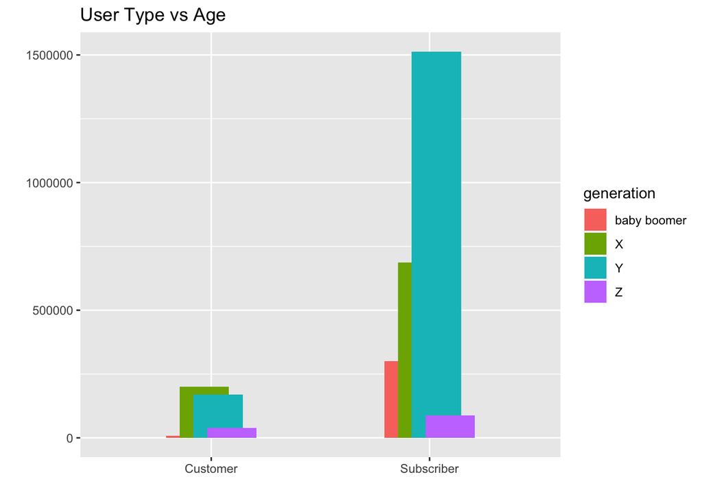

```r
ggplot(augDecData, aes(x= usertype, fill= generation)) + geom_bar( stat = "count" , na.rm= T,
                                                              position = position_dodge(width = 0.25)) + labs(
                                                                title = "User Type vs Age", x= " ", y= ""
                                                              )
```

Majority of customers are between the ages of 54-40

The next plot is Trip duration

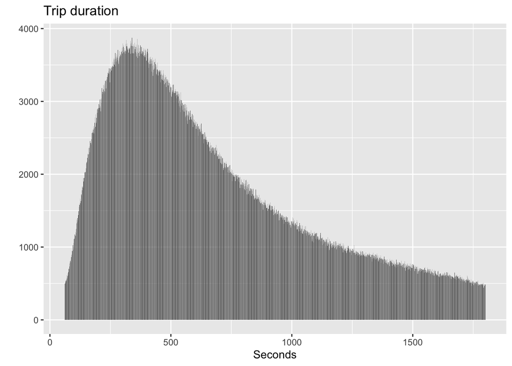

```r
ggplot(augDecData) + geom_histogram(mapping = aes( x= tripduration), stat = "bin",
  position = "stack", binwidth = 0.5,
  na.rm = T
) + labs( title= "Trip duration", x= "Seconds", y= "")
```

The first question to be answer is the Average Trip Duration: -average trip duration

```r
#average in minutes
mean( augDecData$tripduration, trim = 0, na.rm = T) / 60
```

```
## [1] 11.33524
```

The second question is divided into two parts: + a) What are the least popular start stations? + b) What are the most popular stations?

2a)

```r
#descending order
colBar1 <- brewer.pal(10, "Pastel1")
```

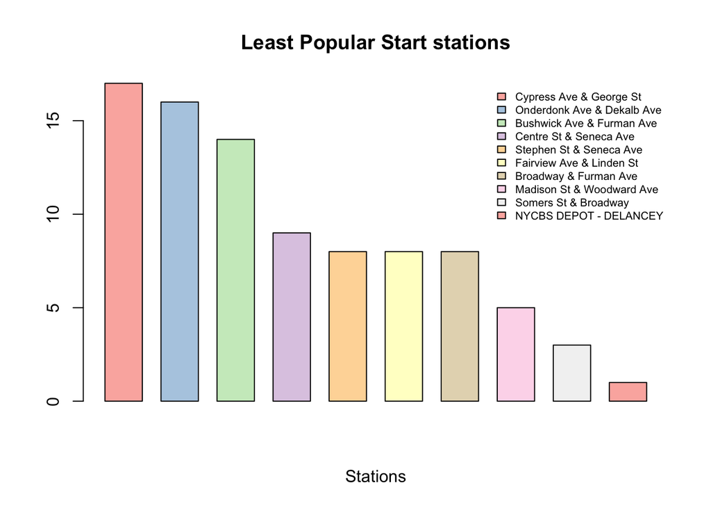

```r
with(diamonds, barplot(rev(sort(table(augDecData$start.station.name))[1:10]), width = 10, main= "Least Popular Start stations", xlab = "Stations", legend.text = T, space= 0.5, col = colBar1, names.arg = F, args.legend= list(x = "topright", bty = "n", cex= 0.65) ) )
```

The least popular station is at NYCBS DEPOT- DELAMCEY with less than 5 users starting from there.

2b)

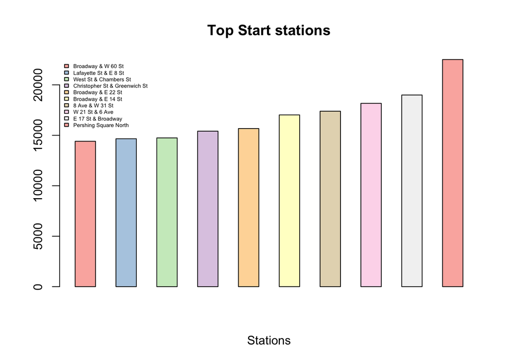

```r
with(diamonds, barplot(rev(sort(table(augDecData$start.station.name), decreasing = T )[1:10]), width = 10, main= "Top Start stations", space= 1, xlab = "Stations", legend.text = T, col= colBar1, names.arg = F, args.legend= list(x = "topleft", bty = "n", cex= 0.45)))
```

The third question to answer is also divided into two parts: + 3a) What are the least popular end stations? + 3b) What are the most popular end stations?

3a)

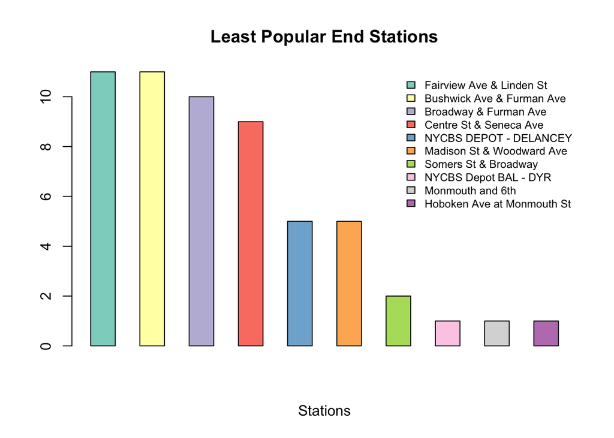

```r
colBar <- brewer.pal(10, "Set3")
with(diamonds, barplot(rev(sort(table(augDecData$end.station.name))[1:10]), width = 10, main= "Least Popular End Stations", space= 1, xlab = "Stations", legend.text = T, col= colBar, names.arg = F, args.legend= list(x = "topright", bty = "n", cex= 0.75)))
```

Hoboken Ave at Monmouth St, Monmouth and 6th, and NYCBS Depot BAL- DYR only register one user.

3b)

[figure not shown]

```r
with(diamonds, barplot(rev(sort(table(augDecData$start.station.name), decreasing = T)[1:10]), width = 10,  main= "Top End stations", space= 1, xlab = "Stations", legend.text = T, col= colBar, names.arg = F, args.legend= list(x = "topleft", bty = "n", cex= 0.45)))
```

The next question is : + What gender bikes more?

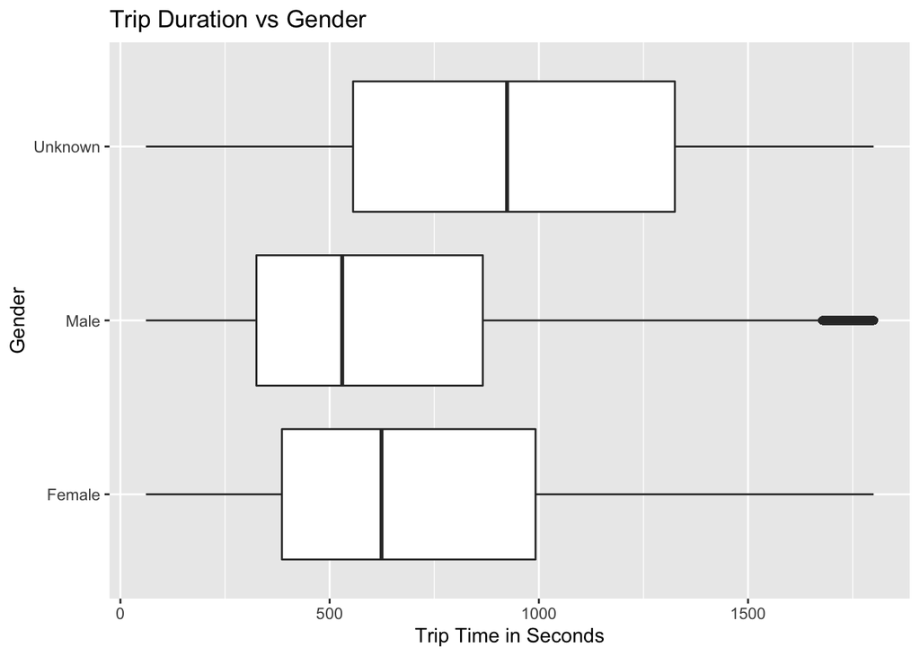

```r
ggplot(augDecData, aes(x= tripduration, y= gender)) + geom_boxplot(na.rm = T) + labs(
  title = "Trip Duration vs Gender", x= "Trip Time in Seconds", y= "Gender")
```

We can conclude that Unknown bikes more. After unknown, females have the highest average trip duration.

Fifth Question: + What age range has the longest trip duration? or Who bikes more?

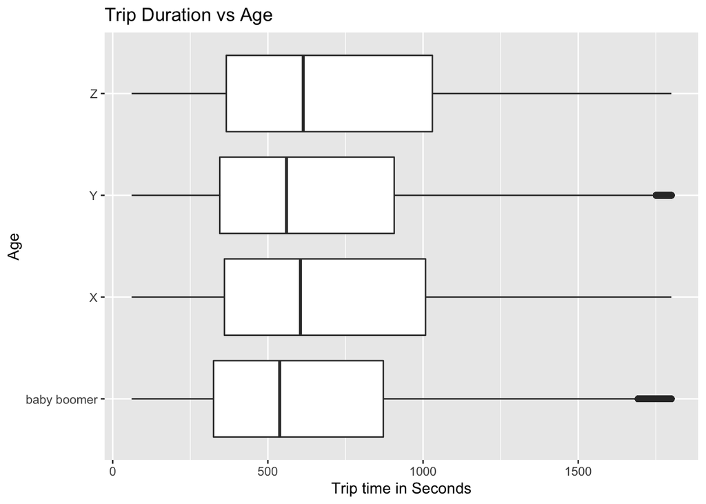

```r
ggplot(augDecData, aes(x= tripduration, y= generation)) + geom_boxplot(na.rm = T)+ labs(
  title = "Trip Duration vs Age", x= "Trip time in Seconds", y= "Age")
```

It looks that Generation Z (10-20 y.o) and Generation X (40-54 y.o ) bike about the same amount of time

The next question is: What day of the week is the busiest?

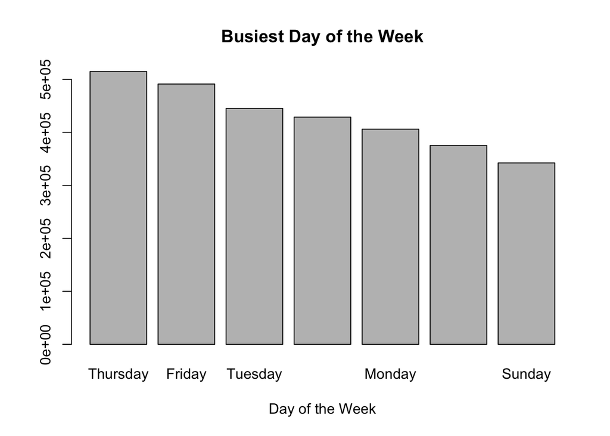

```r
with(diamonds, barplot(rev(sort(table(augDecData$weekday) )[1:7]), width = 10, main= "Busiest Day of the Week", xlab= "Day of the Week"))
```

From what is seen, Thursday is the most popular day to ride a bike. But why is that?

This sixth question has a part a. + 6a) During the busiest day, what gender bikes?

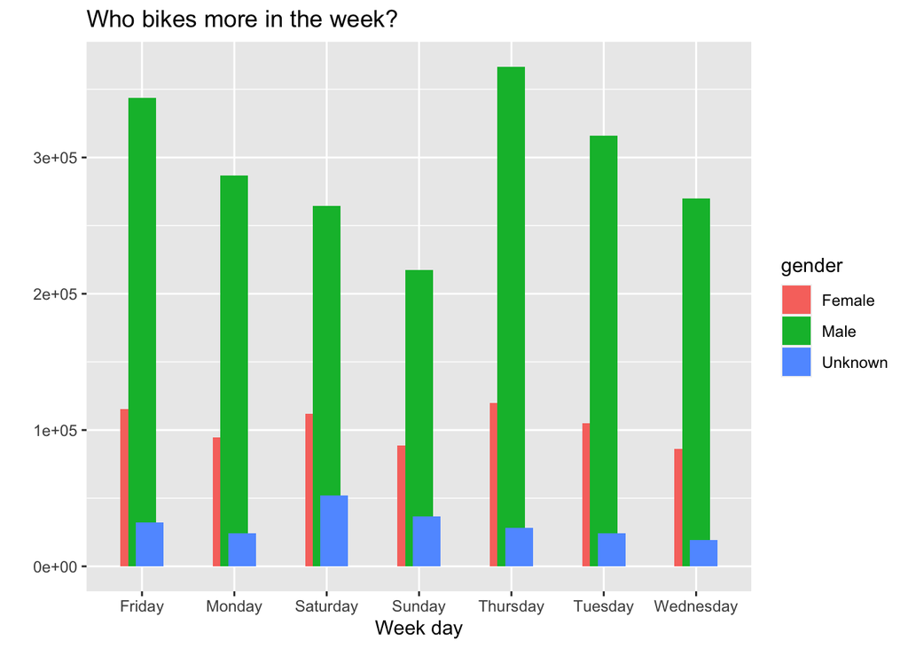

```r
ggplot(augDecData, aes(x= weekday, fill= gender)) + geom_bar( stat = "count" , na.rm= T,
                                                              position = position_dodge(width = 0.25)) + labs(
                                                                title= "Who bikes more in the week?",
                                                                x= "Week day", y= ""
                                                              )
```

Since data from August and December is being used, both data will be compared. First, the Start Date is divided by year, month, and day

```r
augDecData <- augDecData%>% separate(start.date, c("year", "month", "day"), "-")
```

The data is filtered and put into separate data frames.

```r
aug <- filter(augDecData, month== '08')

dec <- filter(augDecData, month== 12)
```

Now, Summer is plotted:

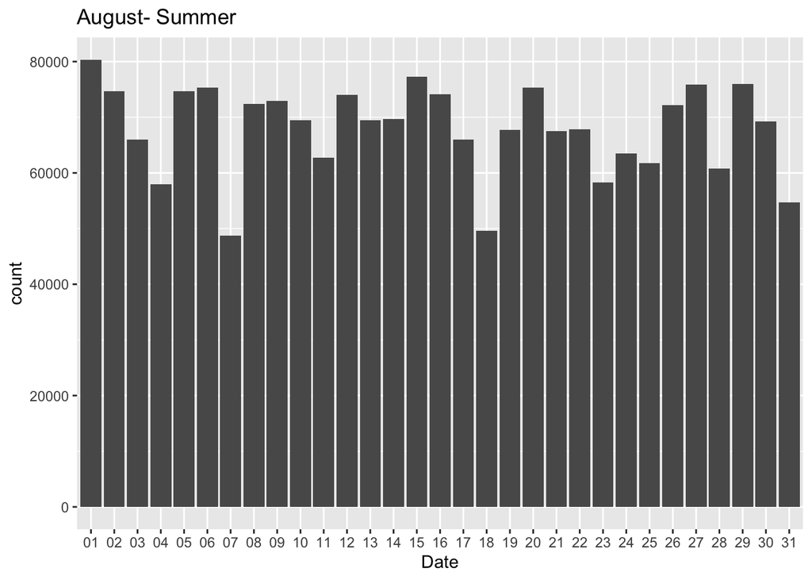

```r
ggplot(aug) + geom_bar(aes(x= aug$day),stat = "count", na.rm= T)+ labs( title= "August- Summer", x= "Date")
```

Then Winter:

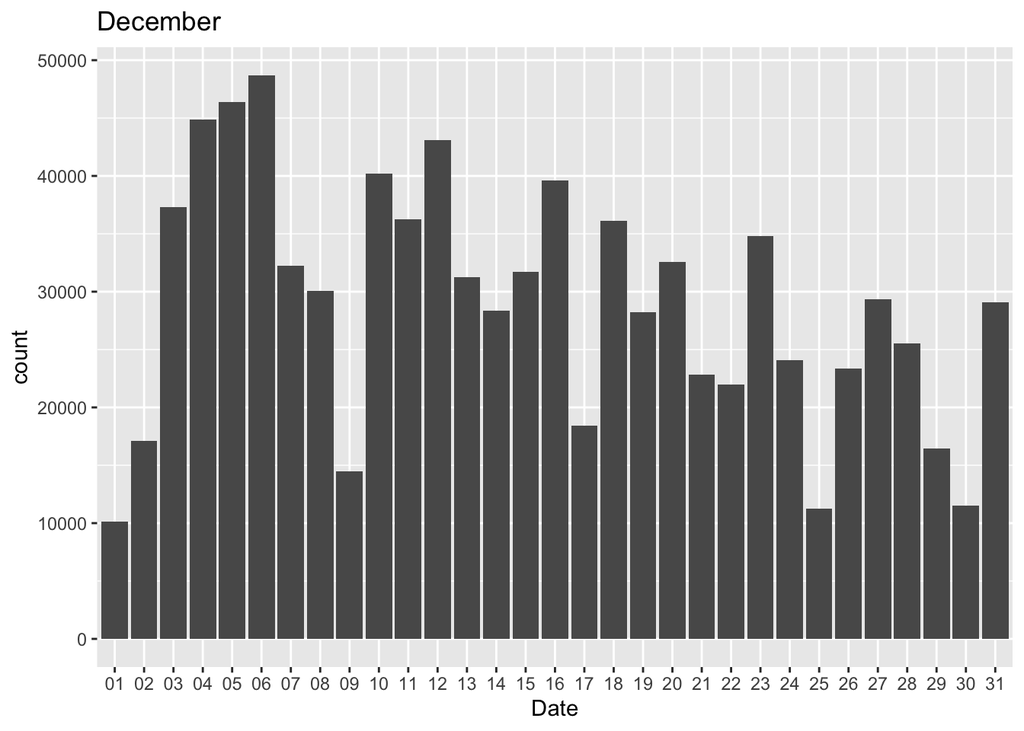

```r
ggplot(dec) + geom_bar(aes(x= dec$day),stat = "count", na.rm= T)+ labs( title= "December", x= "Date")
```

Here is a graph with both data from August and December.

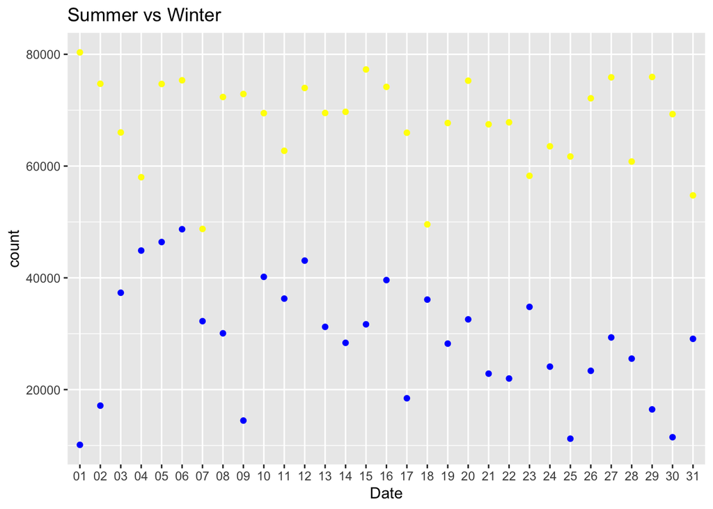

```r
ggplot() +
geom_point(data=aug , aes(x=aug$day), color='yellow', stat = "count", na.rm= T) +
geom_point(data= dec, aes(x=dec$day), color='blue', stat = "count", na.rm= T) + labs( title = "Summer vs Winter", x= "Date")
```

We can see how the day with the lowest amount of users from August is about the same highest amount of users in December.